# Deep_learning_TP1

```python
import tensorflow
import keras
import numpy as np
```

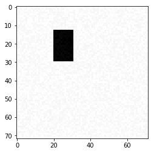

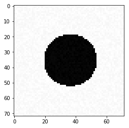

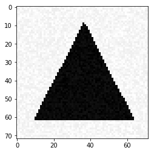

```python
import matplotlib.pyplot as plt
%matplotlib inline
import numpy as np

def generate_a_drawing(figsize, U, V, noise=0.0):
    fig = plt.figure(figsize=(figsize,figsize))
    ax = plt.subplot(111)
    plt.axis('Off')
    ax.set_xlim(0,figsize)
    ax.set_ylim(0,figsize)
    ax.fill(U, V, "k")
    fig.canvas.draw()
    imdata = np.frombuffer(fig.canvas.tostring_rgb(), dtype=np.uint8)[::3].astype(np.float32)
    imdata = imdata + noise * np.random.random(imdata.size)
    plt.close(fig)
    return imdata

def generate_a_rectangle(noise=0.0, free_location=False):
    figsize = 1.0
    U = np.zeros(4)
    V = np.zeros(4)
    if free_location:
        corners = np.random.random(4)
        top = max(corners[0], corners[1])
        bottom = min(corners[0], corners[1])
        left = min(corners[2], corners[3])
        right = max(corners[2], corners[3])
    else:
        side = (0.3 + 0.7 * np.random.random()) * figsize
        top = figsize/2 + side/2
        bottom = figsize/2 - side/2
        left = bottom
        right = top
    U[0] = U[1] = top
    U[2] = U[3] = bottom
    V[0] = V[3] = left
    V[1] = V[2] = right
    return generate_a_drawing(figsize, U, V, noise)


def generate_a_disk(noise=0.0, free_location=False):
    figsize = 1.0
    if free_location:
        center = np.random.random(2)
    else:
        center = (figsize/2, figsize/2)
    radius = (0.3 + 0.7 * np.random.random()) * figsize/2
    N = 50
    U = np.zeros(N)
    V = np.zeros(N)
    i = 0
    for t in np.linspace(0, 2*np.pi, N):
        U[i] = center[0] + np.cos(t) * radius
        V[i] = center[1] + np.sin(t) * radius
        i = i + 1
    return generate_a_drawing(figsize, U, V, noise)

def generate_a_triangle(noise=0.0, free_location=False):
    figsize = 1.0
    if free_location:
        U = np.random.random(3)
        V = np.random.random(3)
    else:
        size = (0.3 + 0.7 * np.random.random())*figsize/2
        middle = figsize/2
        U = (middle, middle+size, middle-size)
        V = (middle+size, middle-size, middle-size)
    imdata = generate_a_drawing(figsize, U, V, noise)
    return [imdata, [U[0], V[0], U[1], V[1], U[2], V[2]]]

plt.figure(1)
im = generate_a_rectangle(10, True)
plt.imshow(im.reshape(72,72), cmap='gray')
plt.figure(2)
im = generate_a_disk(10)
plt.imshow(im.reshape(72,72), cmap='gray')
plt.figure(3)
[im, v] = generate_a_triangle(20, False)
plt.imshow(im.reshape(72,72), cmap='gray')


def generate_dataset_classification(nb_samples, noise=0.0, free_location=False):
    # Getting im_size:
    im_size = generate_a_rectangle().shape[0]
    X = np.zeros([nb_samples,im_size])
    Y = np.zeros(nb_samples)
    print('Creating data:')
    for i in range(nb_samples):
        #if i % 10 == 0:
        #    print(i)
        category = np.random.randint(3)
        if category == 0:
            X[i] = generate_a_rectangle(noise, free_location)
        elif category == 1:
            X[i] = generate_a_disk(noise, free_location)
        else:
            [X[i], V] = generate_a_triangle(noise, free_location)
        Y[i] = category
    print('Data created')
    X = (X + noise) / (255 + 2 * noise)
    return [X, Y]

def generate_test_set_classification(nb_samples):
    np.random.seed(42)
    [X_test, Y_test] = generate_dataset_classification(nb_samples, 20, True)
    Y_test = np_utils.to_categorical(Y_test, 3)
    return [X_test, Y_test]

def generate_dataset_regression(nb_samples, noise=0.0):
    # Getting im_size:
    im_size = generate_a_triangle()[0].shape[0]
    X = np.zeros([nb_samples,im_size])
    Y = np.zeros([nb_samples, 6])
    print('Creating data:')
    for i in range(nb_samples):
        #if i % 10 == 0:
         #   print(i)
        [X[i], Y[i]] = generate_a_triangle(noise, True)
    print('Data created')
    X = (X + noise) / (255 + 2 * noise)
    return [X, Y]

import matplotlib.patches as patches

def visualize_prediction(x, y):
    fig, ax = plt.subplots(figsize=(5, 5))
    I = x.reshape((72,72))
    ax.imshow(I, extent=[-0.15,1.15,-0.15,1.15],cmap='gray')
    ax.set_xlim([0,1])
    ax.set_ylim([0,1])

    xy = y.reshape(3,2)
    tri = patches.Polygon(xy, closed=True, fill = False, edgecolor = 'r', linewidth = 5, alpha = 0.5)
    ax.add_patch(tri)

    plt.show()

def generate_test_set_regression():
    np.random.seed(42)
    [X_test, Y_test] = generate_dataset_regression(300, 20)
    return [X_test, Y_test]
```

1) Build and train a linear classifier in Keras to classify a image into one of the three possible categories (i.e. rectangle, disk, triangle). Try using the stochastic gradient descent optimizer, then the Adam optimizer.

```python
#Generation of the training set
[X_train, Y_train] = generate_dataset_classification(300, 20)
```

```
Creating data:
Data created
```

```python
from keras.models import Sequential
from keras.utils import np_utils
from keras.layers import Dense, Conv2D, MaxPooling2D, Flatten, Dropout
from keras.optimizers import SGD
```

First, we will use the SGD optimizer:

```python
#Transforming the labels from decimal to binary representation
Y_train = np_utils.to_categorical(Y_train, 3)
```

```python
#Using a SGD optimizer with a learning rate of 0.01
sgd = SGD(lr=0.3, decay=1e-5, momentum=0.9, nesterov=True)

linear_model_sgd = Sequential()
units = 3
input_shape = len(X_train[0])
linear_model_sgd.add(Dense(units,activation='softmax',input_shape=(input_shape,),kernel_initializer='normal'))
linear_model_sgd.compile(loss='categorical_crossentropy',\
              optimizer='sgd',\
              metrics=['accuracy'])
linear_model_sgd.fit(X_train, Y_train, batch_size=32, epochs=50, verbose=1)
```

```
<keras.callbacks.History at 0x18367d8f60>
```

```python
#Using Adam optimizer
linear_model_adam = Sequential()
units = 3
input_shape = len(X_train[0])
linear_model_adam.add(Dense(units,activation='softmax',input_shape=(input_shape,),kernel_initializer='random_uniform'))
linear_model_adam.compile(loss='categorical_crossentropy',\
              optimizer='adam',\
              metrics=['accuracy'])
linear_model_adam.fit(X_train, Y_train, batch_size=32, epochs=50, verbose=1)
```

```
<keras.callbacks.History at 0x184fb51fd0>
```

```python
#Test on centered images
[X_test_1, Y_test_1] = generate_dataset_classification(300, 20)
Y_test_1 = np_utils.to_categorical(Y_test_1, 3)
```

```
Creating data:
Data created
```

```python
evaluation_sgd = linear_model_sgd.evaluate(X_test_1,Y_test_1,verbose=0)
print("Accuray of the linear model on test dataset of centered images using SGD optimizer is: "\
      ,round(100*evaluation_sgd[1],2),"%, and the loss is: ", round(evaluation_sgd[0],2))
evaluation_adam = linear_model_adam.evaluate(X_test_1,Y_test_1,verbose=0)
print("Accuray of the linear model on test dataset of centered images using Adam optimizer is: ",\
      round(100*evaluation_adam[1],2),"%, and the loss is: ", round(evaluation_adam[0],2))
```

```
Accuray of the linear model on test dataset of centered images using SGD optimizer is:  68.33 %, and the loss is:  5.07
Accuray of the linear model on test dataset of centered images using Adam optimizer is:  98.33 %, and the loss is:  0.06
```

The adam optimizer performs better than the SGD optimizer (having tried different values of lr and decay) using the linear network architecture, the accuracy on training is 100% and 65.67% using Adam and SGD optimizers respectively. Since Adam is an adaptative method that automatically adapt the step length for each parameter, it stores an exponentially decaying average of past squared gradients and an exponentially decaying average of past gradients in order to estimate the first and second moment of gradients, Automatically, it gives a better stepsize and then better convergence.

We can see that the performance on centred images test dataset is 98.33 and 68.33 using respectively Adam and SGD optimizers respectively. Which is a good performance and we can see that there is no overfitting for the two methods so no need to do a regularization, it's also duo to the number of training samples which is 300 (not huge).

```python
#Test on non centered images
[X_test_2, Y_test_2] = generate_test_set_classification(300)
```

```
Creating data:
Data created
```

```python
evaluation_sgd = linear_model_sgd.evaluate(X_test_2,Y_test_2,verbose=0)
print("Accuray on test dataset of free-position images using SGD optimizer is: ", \
      round(100*evaluation_sgd[1],2),"%, and the loss is: ", round(evaluation_sgd[0],2))
evaluation_adam = linear_model_adam.evaluate(X_test_2,Y_test_2,verbose=0)
print("Accuray on test dataset of free-position images using Adam optimizer is: ", \
      round(100*evaluation_adam[1],2),"%, and the loss is: ", round(evaluation_adam[0],2))
```

```
Accuray on test dataset of free-position images using SGD optimizer is:  31.67 %, and the loss is:  6.65
Accuray on test dataset of free-position images using Adam optimizer is:  62.0 %, and the loss is:  0.75
```

Here we will try a non linear classifier by breaking the linearity using the non-linear activation function ReLu

```python
#Using a SGD optimizer with a learning rate of 0.01
sgd = SGD(lr=0.01, decay=1e-6, momentum=0.9, nesterov=True)

model_sgd = Sequential()
units = 64
input_shape = len(X_train[0])
model_sgd.add(Dense(units,activation='relu',input_shape=(input_shape,),kernel_initializer='random_uniform'))
model_sgd.add(Dense(3,activation='softmax'))
model_sgd.compile(loss='categorical_crossentropy',\
              optimizer='sgd',\
              metrics=['accuracy'])
model_sgd.fit(X_train, Y_train, batch_size=32, epochs=50, verbose=1)
```

```
<keras.callbacks.History at 0x1841c0ccf8>
```

```python
#Using Adam optimizer
model_adam = Sequential()
units = 64
input_shape = len(X_train[0])
model_adam.add(Dense(units,activation='relu',input_shape=(input_shape,),kernel_initializer='normal'))
model_adam.add(Dense(3,activation='softmax'))
model_adam.compile(loss='categorical_crossentropy',\
              optimizer='adam',\
              metrics=['accuracy'])
model_adam.fit(X_train, Y_train, batch_size=32, epochs=50, verbose=1)
```

```
<keras.callbacks.History at 0x1841581cc0>
```

```python
evaluation_sgd = model_sgd.evaluate(X_test_1,Y_test_1,verbose=0)
print("Accuray of the non linear model on test dataset of centered images using SGD optimizer \
is:\n ",round(100*evaluation_sgd[1],2),"%, and the loss is: ", round(evaluation_sgd[0],2))
evaluation_adam = model_adam.evaluate(X_test_1,Y_test_1,verbose=0)
print("Accuray of the linear model on test dataset of centered images using Adam optimizer is: \n\
",round(100*evaluation_adam[1],2),"%, and the loss is: ", round(evaluation_adam[0],2))
```

```
Accuray of the non linear model on test dataset of centered images using SGD optimizer is:
  74.67 %, and the loss is:  0.81
Accuray of the linear model on test dataset of centered images using Adam optimizer is:
 98.33 %, and the loss is:  0.06
```

```python
evaluation_sgd = model_sgd.evaluate(X_test_2,Y_test_2,verbose=0)
print("Accuray on test dataset of free-position images using SGD optimizer is: ", \
      round(100*evaluation_sgd[1],2),"%, and the loss is: ", round(evaluation_sgd[0],2))
evaluation_adam = model_adam.evaluate(X_test_2,Y_test_2,verbose=0)
print("Accuray on test dataset of free-position images using Adam optimizer is: ", \
      round(100*evaluation_adam[1],2),"%, and the loss is: ", round(evaluation_adam[0],2))
```

```
Accuray on test dataset of free-position images using SGD optimizer is:  27.33 %, and the loss is:  3.21
Accuray on test dataset of free-position images using Adam optimizer is:  37.33 %, and the loss is:  3.73
```

2) Visualization of the Solution: Visualize the 3 columns as images.

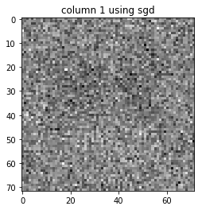

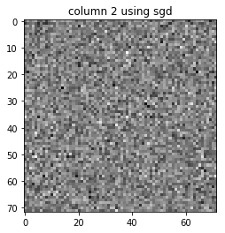

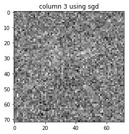

```python
weights_sgd = linear_model_sgd.get_weights()[0]
plt.figure(1)
im = weights_sgd[:,0]
plt.imshow(im.reshape(72,72), cmap='gray')
plt.title('column 1 using sgd')
plt.figure(2)
im = weights_sgd[:,1]
plt.imshow(im.reshape(72,72), cmap='gray')
plt.title('column 2 using sgd')
plt.figure(3)
im = weights_sgd[:,2]
plt.title('column 3 using sgd')
plt.imshow(im.reshape(72,72), cmap='gray')
```

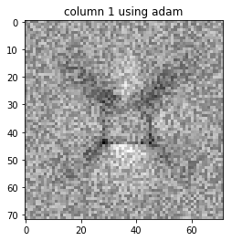

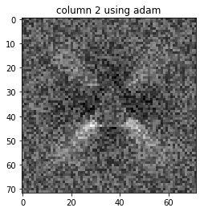

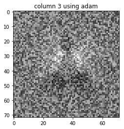

```python
weights_adam = linear_model_adam.get_weights()[0]
plt.figure(1)
im = weights_adam[:,0]
plt.imshow(im.reshape(72,72), cmap='gray')
plt.title('column 1 using adam')
plt.figure(2)
im = weights_adam[:,1]
plt.imshow(im.reshape(72,72), cmap='gray')
plt.title('column 2 using adam')
plt.figure(3)
im = weights_adam[:,2]
plt.title('column 3 using adam')
plt.imshow(im.reshape(72,72), cmap='gray')
```

We can see that using the SGD optimizer, the visualization of the weights after convergence don't give usual or noticeable forms, the image given by the columns using SGD optimizer are close to a white noise (we can see in the first column image a shape close to an X in the center of the image, but not too bright/dark) unlike the images of the columns using Adam optimizer where we can notice some shapes in the center of each image (this thanks to the convergence to a 100% accuracy on training samples).

4 A More Difficult Classification Problem : Retrain your linear classifier on this new training set. Add the metrics=[’accuracy’] parameter when calling the compile function to get the classification error in addition to the loss value.

```python
#Increased the training samples to see if the performance increases
[X_train_2, Y_train_2] = generate_dataset_classification(1000, 20, True)
```

```
Creating data:
Data created
```

```python
#Transforming the labels from decimal to binary representation
Y_train_2 = np_utils.to_categorical(Y_train_2, 3)
```

```python
#Using Adam optimizer
linear_model_adam = Sequential()
units = 3
input_shape = len(X_train_2[0])
linear_model_adam.add(Dense(units,activation='softmax',input_shape=(input_shape,),\
                            kernel_initializer='random_uniform'))
linear_model_adam.compile(loss='categorical_crossentropy',\
              optimizer='adam',\
              metrics=['accuracy'])
linear_model_adam.fit(X_train_2, Y_train_2, batch_size=100, epochs=200, verbose=1)
```

```
<keras.callbacks.History at 0x1a6fcf7da0>
```

```python
evaluation_adam = linear_model_adam.evaluate(X_test_2,Y_test_2,verbose=0)
print("Accuray on test dataset of free-position images using Adam optimizer is: ", \
      round(100*evaluation_adam[1],2),"%, and the loss is: ", round(evaluation_adam[0],2))
evaluation_adam_1 = linear_model_adam.evaluate(X_test_1,Y_test_1,verbose=0)
print("Accuray on test dataset of centered images using Adam optimizer is: ", \
      round(100*evaluation_adam_1[1],2),"%, and the loss is: ", round(evaluation_adam_1[0],2))
```

```
Accuray on test dataset of free-position images using Adam optimizer is:  62.0 %, and the loss is:  0.75
Accuray on test dataset of centered images using Adam optimizer is:  43.0 %, and the loss is:  1.74
```

```python
X_train_3 = np.concatenate((X_train,X_train_2))
Y_train_3 = np.concatenate((Y_train,Y_train_2))
```

```python
from sklearn.utils import shuffle
[X_train_3,Y_train_3] = shuffle(X_train_3,Y_train_3)
```

```python
#Using Adam optimizer
linear_model_adam_bis = Sequential()
units = 3
input_shape = len(X_train_2[0])
linear_model_adam_bis.add(Dense(units,activation='softmax',input_shape=(input_shape,),\
                            kernel_initializer='random_uniform'))
linear_model_adam_bis.compile(loss='categorical_crossentropy',\
              optimizer='adam',\
              metrics=['accuracy'])
linear_model_adam_bis.fit(X_train_3, Y_train_3, batch_size=100, epochs=200, verbose=1)
```

```
<keras.callbacks.History at 0x185e4f7c18>
```

```python
evaluation_adam = linear_model_adam_bis.evaluate(X_test_2,Y_test_2,verbose=0)
print("Accuray on test dataset of free-position images using Adam optimizer is: ", \
      round(100*evaluation_adam[1],2),"%, and the loss is: ", round(evaluation_adam[0],2))
evaluation_adam_1 = linear_model_adam_bis.evaluate(X_test_1,Y_test_1,verbose=0)
print("Accuray on test dataset of centered images using Adam optimizer is: ", \
      round(100*evaluation_adam_1[1],2),"%, and the loss is: ", round(evaluation_adam_1[0],2))
```

```
Accuray on test dataset of free-position images using Adam optimizer is:  58.0 %, and the loss is:  0.92
Accuray on test dataset of centered images using Adam optimizer is:  84.0 %, and the loss is:  0.49
```

```python
X_test_3 = np.concatenate((X_test_1,X_test_2))
Y_test_3 = np.concatenate((Y_test_1,Y_test_2))
```

```python
evaluation_adam_2 = linear_model_adam_bis.evaluate(X_test_3,Y_test_3,verbose=0)
print("Accuray on the merged test set using Adam optimizer is: ", \
      round(100*evaluation_adam_2[1],2),"%, and the loss is: ", round(evaluation_adam_2[0],2))
```

```
Accuray on the merged test set using Adam optimizer is:  74.17 %, and the loss is:  0.68
```

By merging the two training sets of centered and non centered images, we can see that the performance on the centered images test set has increased from 43.0 % to 84.0 % and the one on non centered test set has decreased from 62.0 % to 58.0 % which can be neglected in the faviour of the increase in the performance on the centered images.

However, the performance still not very good on the non centered images, next we will use a convolutional neural network in order to extract the relevant features from images.

Train a convolutional (not-too-)deep network on this new dataset. What is the value of the loss function on this test set when using your deep network?

```python
#Reshape the input to adapt it to the filters
X_train_4 = np.array(list((map(lambda x: x.reshape(72,72,1), X_train_2))))
X_test_4 = np.array(list((map(lambda x: x.reshape(72,72,1), X_test_2))))
X_test_5 = np.array(list((map(lambda x: x.reshape(72,72,1), X_test_1))))
```

```python
#Using Adam optimizer
conv_model_adam = Sequential()
units = 128
input_shape = len(X_train_2[0])
conv_model_adam.add(Conv2D(16, (5,5), activation='relu',\
          input_shape=(72, 72, 1)))
conv_model_adam.add(MaxPooling2D(pool_size=(2, 2)))
conv_model_adam.add(Flatten())
#conv_model_adam.add(Dense(128, activation='relu'))
conv_model_adam.add(Dense(3, activation='softmax'))
print(conv_model_adam.input_shape)
conv_model_adam.compile(loss='categorical_crossentropy',\
              optimizer='adam',\
              metrics=['accuracy'])
conv_model_adam.fit(X_train_4, Y_train_2, batch_size=100, epochs=100, verbose=1)
```

```
(None, 72, 72, 1)
```

```
<keras.callbacks.History at 0x185e508048>
```

```python
evaluation_adam = conv_model_adam.evaluate(X_test_4,Y_test_2,verbose=0)
print("Accuray on test dataset of free-position images using Adam optimizer is: ", \
      round(100*evaluation_adam[1],2),"%, and the loss is: ", round(evaluation_adam[0],2))
evaluation_adam_1 = conv_model_adam.evaluate(X_test_5,Y_test_1,verbose=0)
print("Accuray on test dataset of centered images using Adam optimizer is: ", \
      round(100*evaluation_adam_1[1],2),"%, and the loss is: ", round(evaluation_adam_1[0],2))
```

```
Accuray on test dataset of free-position images using Adam optimizer is:  84.33 %, and the loss is:  0.46
Accuray on test dataset of centered images using Adam optimizer is:  81.67 %, and the loss is:  1.24
```

```python
#Reshape the merged sets (free-pos + centered)
X_train_6 = np.array(list((map(lambda x: x.reshape(72,72,1), X_train_3))))
X_test_6 = np.array(list((map(lambda x: x.reshape(72,72,1), X_test_3))))
```

```python
evaluation_adam_2 = conv_model_adam.evaluate(X_test_6,Y_test_3,verbose=0)
print("Accuray on the merged test set using Adam optimizer is: ", \
      round(100*evaluation_adam_2[1],2),"%, and the loss is: ", round(evaluation_adam_2[0],2))
```

```
Accuray on the merged test set using Adam optimizer is:  83.0 %, and the loss is:  0.85
```

Using the convolutional neural network as suggested in the paper with one fully-connected layer gives a performance of 84.33 % on free-position test set and 81.67 % on centered test set while it's only trained on the 1000 free-position set. Which is better performance that the one given by the previous artificial neural network. Next we will use 2 fully connected layer and train over the merged train set and see how it changes the performance.

The performance when merged the free-pos and centered test sets is 83.0 % and the loss is 0.85.

```python
#Using Adam optimizer
conv_model_adam_bis = Sequential()
units = 128
input_shape = len(X_train_2[0])
conv_model_adam_bis.add(Conv2D(16, (5,5), activation='relu',\
          input_shape=(72, 72, 1)))
conv_model_adam_bis.add(MaxPooling2D(pool_size=(2, 2)))
conv_model_adam_bis.add(Flatten())
conv_model_adam_bis.add(Dense(128, activation='relu'))
conv_model_adam_bis.add(Dense(3, activation='softmax'))
print(conv_model_adam_bis.input_shape)
conv_model_adam_bis.compile(loss='categorical_crossentropy',\
              optimizer='adam',\
              metrics=['accuracy'])
conv_model_adam_bis.fit(X_train_6, Y_train_3, batch_size=100, epochs=100, verbose=1)
```

```
(None, 72, 72, 1)
```

```
<keras.callbacks.History at 0x18591585f8>
```

```python
evaluation_adam = conv_model_adam_bis.evaluate(X_test_4,Y_test_2,verbose=0)
print("Accuray on test dataset of free-position images using Adam optimizer is: ", \
      round(100*evaluation_adam[1],2),"%, and the loss is: ", round(evaluation_adam[0],2))
evaluation_adam_1 = conv_model_adam_bis.evaluate(X_test_5,Y_test_1,verbose=0)
print("Accuray on test dataset of centered images using Adam optimizer is: ", \
      round(100*evaluation_adam_1[1],2),"%, and the loss is: ", round(evaluation_adam_1[0],2))
```

```
Accuray on test dataset of free-position images using Adam optimizer is:  89.67 %, and the loss is:  0.39
Accuray on test dataset of centered images using Adam optimizer is:  99.33 %, and the loss is:  0.02
```

```python
evaluation_adam_2 = conv_model_adam_bis.evaluate(X_test_6,Y_test_3,verbose=0)
print("Accuray on the merged test set using Adam optimizer is: ", \
      round(100*evaluation_adam_2[1],2),"%, and the loss is: ", round(evaluation_adam_2[0],2))
```

```
Accuray on the merged test set using Adam optimizer is:  94.5 %, and the loss is:  0.21
```

By using a hidden fully connected layer with a Relu activation function and by training it over the merged training set made of the 1000 free-pos and 300 centered images, we can see that the perfomance on free-pos and centered images has increased to 89.67% and 99.33% respectively comparing it to the previous conv network containing only one fullt connected layer.

5 A Regression Problem : Build and train a regressor on this data.

```python
[X_train_7, Y_train_7] = generate_dataset_regression(300, 20)
[X_test_7, Y_test_7] = generate_test_set_regression()
```

```
Creating data:
Data created
Creating data:
Data created
```

```python
means_train = np.mean(Y_train_7,axis=0)
std_train = np.std(Y_train_7,axis=0)
means_test = np.mean(Y_test_7,axis=0)
std_test = np.std(Y_test_7,axis=0)
```

```python
from keras import regularizers
```

```python
#normalizing data
from sklearn import preprocessing
Y_train_7_norm = preprocessing.scale(Y_train_7)
Y_test_7_norm = preprocessing.scale(Y_test_7)
```

```python
#Artificial neural network
reg_model = Sequential()
units = 128
input_dim = len(X_train_7[0])
reg_model.add(Dense(units , input_dim=input_dim, kernel_initializer='normal', activation='relu'))
reg_model.add(Dense(6, kernel_initializer='normal'))
reg_model.compile(loss='mean_squared_error', optimizer='adam')
reg_model.fit(X_train_7, Y_train_7_norm, batch_size=32, epochs=50,\
              validation_split= 0.2, verbose=1)
```

```
Train on 240 samples, validate on 60 samples
```

```
<keras.callbacks.History at 0x1a6b71dd30>
```

```python
reg_model.evaluate(X_test_7,Y_test_7_norm)
```

```
0.89727258523305253
```

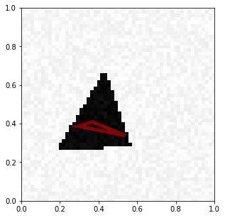

```python
#Trying to visuliaze a prediction on train data
A = X_train_7[0].reshape(1, X_train_7[0].shape[0])
C =reg_model.predict(A)
visualize_prediction(X_train_7[0], C*std_train+means_train)
```

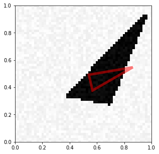

```python
#Trying to visuliaze a prediction on train data
A = X_test_7[0].reshape(1, X_test_7[0].shape[0])
C = reg_model.predict(A)
visualize_prediction(X_test_7[0], C*std_test+means_test)
```

```python
X_train_7_bis = np.array(list((map(lambda x: x.reshape(72,72,1), X_train_7))))
X_test_7_bis = np.array(list((map(lambda x: x.reshape(72,72,1), X_test_7))))
```

```python
#Using Adam optimizer
conv_model_adam_bis = Sequential()
units = 128
input_shape = len(X_train_7[0])
reg_model.add(Dropout(0.3, input_shape=(72, 72, 1)))
conv_model_adam_bis.add(Conv2D(16, (5,5), activation='relu',\
          input_shape=(72, 72, 1)))
conv_model_adam_bis.add(MaxPooling2D(pool_size=(2, 2)))
conv_model_adam_bis.add(Flatten())
conv_model_adam_bis.add(Dense(64, activation='relu', kernel_initializer='normal'))
conv_model_adam_bis.add(Dense(6, kernel_initializer='normal'))

conv_model_adam_bis.compile(loss='mean_squared_error',\
              optimizer='adam')
conv_model_adam_bis.fit(X_train_7_bis, Y_train_7_norm, batch_size=32,\
                        epochs=200,validation_split=0.1, verbose=1)
```

```
Train on 270 samples, validate on 30 samples
```

```
<keras.callbacks.History at 0x1a7eaa3c18>
```

```python
conv_model_adam_bis.evaluate(X_test_7_bis,Y_test_7_norm)
```

```
1.0727239259084065
```

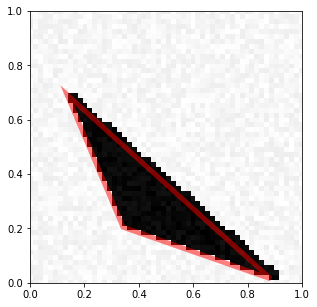

```python
#Trying to visuliaze a prediction on train data
C = conv_model_adam_bis.predict(np.array([X_train_7_bis[1]]))
visualize_prediction(X_train_7[1], C*std_train+means_train)
```

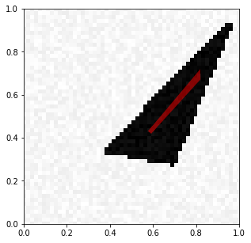

```python
#Trying to visuliaze a prediction on train data
C = conv_model_adam_bis.predict(np.array([X_test_7_bis[0]]))
visualize_prediction(X_test_7[0], C*std_test+means_test)
```

```python
#Using Adam optimizer
conv_model_adam_bis = Sequential()
units = 128
input_shape = len(X_train_7[0])
reg_model.add(Dropout(0.3, input_shape=(72, 72, 1)))
conv_model_adam_bis.add(Conv2D(16, (5,5), activation='relu',\
          input_shape=(72, 72, 1)))
conv_model_adam_bis.add(MaxPooling2D(pool_size=(2, 2)))
conv_model_adam_bis.add(Flatten())
conv_model_adam_bis.add(Dense(32, activation='relu', kernel_initializer='normal'))
conv_model_adam_bis.add(Dense(6, kernel_initializer='normal'))

conv_model_adam_bis.compile(loss='mean_squared_error',\
              optimizer='adam')
conv_model_adam_bis.fit(X_train_7_bis, Y_train_7_norm, batch_size=32,\
                        epochs=60,validation_split=0.1, verbose=1)
```

```
Train on 270 samples, validate on 30 samples
```

```
<keras.callbacks.History at 0x1a92639908>
```

```python
conv_model_adam_bis.evaluate(X_test_7_bis,Y_test_7_norm)
```

```
0.78091569344202683
```

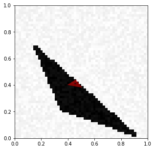

```python
#Trying to visuliaze a prediction on train data
C = conv_model_adam_bis.predict(np.array([X_train_7_bis[1]]))
visualize_prediction(X_train_7[1], C*std_train+means_train)
```

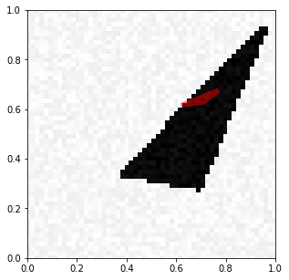

```python
#Trying to visuliaze a prediction on train data
C = conv_model_adam_bis.predict(np.array([X_test_7_bis[0]]))
visualize_prediction(X_test_7[0], C*std_test+means_test)
```

We can see that the convolutionnal model overfit when the number of units in the dense layer is large, however even if we want to control the overfitting, the flexibility still poor either on the train or the test data, this can be solved by develloping a more deep CNN.